# Data Programming

Project

Author

Affiliation

Andrej Natev

FAMNIT, University of Primorska

Published

June 16, 2024

# Introduction

The music industry is a complex and rapidly evolving field, where predicting the success of a song can have significant commercial and cultural implications. Leveraging data science and machine learning, this project aims to predict hit songs using metadata from the Spotify API(Lamere, n.d.). By analyzing various audio features, we seek to understand what makes a song popular and how different characteristics contribute to its success.

## Objectives

This study aims to:

- Extract track data from Spotify using Spotipy(Lamere, n.d.), the library for Python.
- Analyze the data and find some correlation between the features and popularity.
- Visualize the results that were found.

# Libraries

```r
library(tidyverse)
library(ggplot2)
```

# Presentation of the Data

```r
spotify_data <- read_csv("check (3).csv")

head(spotify_data)
```

```
# A tibble: 6 × 18
   ...1 name           popularity id    danceability energy   key loudness  mode
  <dbl> <chr>               <dbl> <chr>        <dbl>  <dbl> <dbl>    <dbl> <dbl>
1     0 "Give Me Ever…         86 4QNp…        0.671 0.939      8    -3.21     1
2     1 "Heather"              87 4xqr…        0.357 0.425      5    -7.30     1
3     2 "The Middle"           83 6GG7…        0.643 0.849      2    -5.43     1
4     3 "What Was I M…         91 6wf7…        0.444 0.0911     0   -17.7      1
5     4 "Flowers"              91 7DSA…        0.706 0.691      0    -4.78     1
6     5 "No Te Quiere…         84 3Cx4…        0.76  0.646      6    -5.01     1
# ℹ 9 more variables: speechiness <dbl>, acousticness <dbl>,
#   instrumentalness <dbl>, liveness <dbl>, valence <dbl>, tempo <dbl>,
#   duration_ms <dbl>, time_signature <dbl>, hit <chr>
```

```r
str(spotify_data)
```

```
spc_tbl_ [1,299 × 18] (S3: spec_tbl_df/tbl_df/tbl/data.frame)
 $ ...1            : num [1:1299] 0 1 2 3 4 5 6 10 11 12 ...
 $ name            : chr [1:1299] "Give Me Everything (feat. Nayer)" "Heather" "The Middle" "What Was I Made For? [From The Motion Picture \"Barbie\"]" ...
 $ popularity      : num [1:1299] 86 87 83 91 91 84 83 75 74 80 ...
 $ id              : chr [1:1299] "4QNpBfC0zvjKqPJcyqBy9W" "4xqrdfXkTW4T0RauPLv3WA" "6GG73Jik4jUlQCkKg9JuGO" "6wf7Yu7cxBSPrRlWeSeK0Q" ...
 $ danceability    : num [1:1299] 0.671 0.357 0.643 0.444 0.706 0.76 0.692 0.505 0.697 0.44 ...
 $ energy          : num [1:1299] 0.939 0.425 0.849 0.0911 0.691 0.646 0.684 0.71 0.235 0.317 ...
 $ key             : num [1:1299] 8 5 2 0 0 6 6 3 7 8 ...
 $ loudness        : num [1:1299] -3.21 -7.3 -5.43 -17.66 -4.78 ...
 $ mode            : num [1:1299] 1 1 1 1 1 1 1 1 1 1 ...
 $ speechiness     : num [1:1299] 0.161 0.0333 0.0526 0.0307 0.0633 0.068 0.155 0.0321 0.0534 0.0531 ...
 $ acousticness    : num [1:1299] 0.191 0.584 0.0371 0.959 0.0584 0.361 0.131 0.19 0.62 0.891 ...
 $ instrumentalness: num [1:1299] 0.00 0.00 0.00 1.05e-06 6.99e-05 1.09e-04 0.00 2.50e-04 1.44e-04 4.78e-06 ...
 $ liveness        : num [1:1299] 0.298 0.322 0.058 0.098 0.0232 0.254 0.156 0.329 0.107 0.141 ...
 $ valence         : num [1:1299] 0.53 0.27 0.903 0.142 0.632 0.576 0.406 0.428 0.378 0.268 ...
 $ tempo           : num [1:1299] 129 102.1 162.2 78.4 118 ...
 $ duration_ms     : num [1:1299] 252307 198040 165853 222370 200600 ...
 $ time_signature  : num [1:1299] 4 3 4 4 4 4 4 4 4 3 ...
 $ hit             : chr [1:1299] "hit" "hit" "hit" "hit" ...
 - attr(*, "spec")=
  .. cols(
  ..   ...1 = col_double(),
  ..   name = col_character(),
  ..   popularity = col_double(),
  ..   id = col_character(),
  ..   danceability = col_double(),
  ..   energy = col_double(),
  ..   key = col_double(),
  ..   loudness = col_double(),
  ..   mode = col_double(),
  ..   speechiness = col_double(),
  ..   acousticness = col_double(),
  ..   instrumentalness = col_double(),
  ..   liveness = col_double(),
  ..   valence = col_double(),
  ..   tempo = col_double(),
  ..   duration_ms = col_double(),
  ..   time_signature = col_double(),
  ..   hit = col_character()
  .. )
 - attr(*, "problems")=<externalptr>
```

# Dataset Columns

- name: Name of the song.
- popularity: Popularity score of the song.
- id: Spotify ID of the song.
- danceability: Danceability score of the song.
- energy: Energy score of the song.
- key: Key of the song.
- loudness: Loudness of the song.
- mode: Mode of the song.
- speechiness: Speechiness score of the song.
- acousticness: Acousticness score of the song.
- instrumentalness: Instrumentalness score of the song.
- liveness: Liveness score of the song.
- valence: Valence score of the song.
- tempo: Tempo of the song.
- duration_ms: Duration of the song in milliseconds.
- time_signature: Time signature of the song.
- hit: Indicates whether the song is a hit or not.

# Data Aggregation

```r
audio_summary <- spotify_data %>%
  summarise(across(c(danceability, energy, tempo), list(mean = ~mean(.x, na.rm = TRUE), sd = ~sd(.x, na.rm = TRUE))))

audio_summary
```

```
# A tibble: 1 × 6
  danceability_mean danceability_sd energy_mean energy_sd tempo_mean tempo_sd
              <dbl>           <dbl>       <dbl>     <dbl>      <dbl>    <dbl>
1             0.599           0.177       0.620     0.261       121.     29.2
```

## Distribution of Songs Based on Each Feature

```r
create_buckets <- function(data, feature_name, n_buckets = 10) {
  data %>%
    mutate(bucket = ntile(.data[[feature_name]], n_buckets)) %>%
    group_by(bucket) %>%
    summarise(count = n()) %>%
    ungroup() %>%
    mutate(feature = feature_name)
}

bucket_features <- function(data, features, n_buckets = 10) {
  bind_rows(lapply(features, function(feature) create_buckets(data, feature, n_buckets)))
}

features_to_bucket <- c("danceability", "energy", "key", "loudness", "mode", "speechiness", "acousticness", "instrumentalness", "liveness", "valence", "tempo", "duration_ms", "time_signature")

bucketed_counts <- bucket_features(spotify_data, features_to_bucket)

bucketed_counts
```

```
# A tibble: 130 × 3
   bucket count feature
    <int> <int> <chr>
 1      1   130 danceability
 2      2   130 danceability
 3      3   130 danceability
 4      4   130 danceability
 5      5   130 danceability
 6      6   130 danceability
 7      7   130 danceability
 8      8   130 danceability
 9      9   130 danceability
10     10   129 danceability
# ℹ 120 more rows
```

## Average Popularity by Feature

```r
create_avg_popularity_buckets <- function(data, feature_name, n_buckets = 10) {
  data %>%
    mutate(bucket = ntile(.data[[feature_name]], n_buckets)) %>%
    group_by(bucket) %>%
    summarise(avg_popularity = mean(popularity, na.rm = TRUE)) %>%
    ungroup() %>%
    mutate(feature = feature_name)
}

bucket_avg_popularity_features <- function(data, features, n_buckets = 10) {
  bind_rows(lapply(features, function(feature) create_avg_popularity_buckets(data, feature, n_buckets)))
}

bucketed_avg_popularity <- bucket_avg_popularity_features(spotify_data, features_to_bucket)

bucketed_avg_popularity
```

```
# A tibble: 130 × 3
   bucket avg_popularity feature
    <int>          <dbl> <chr>
 1      1           56.2 danceability
 2      2           60.1 danceability
 3      3           59.5 danceability
 4      4           61.8 danceability
 5      5           60.4 danceability
 6      6           58.3 danceability
 7      7           62.4 danceability
 8      8           60.1 danceability
 9      9           63.2 danceability
10     10           61.7 danceability
# ℹ 120 more rows
```

# Exploratory Data Analysis

## Distribution of Song Popularity

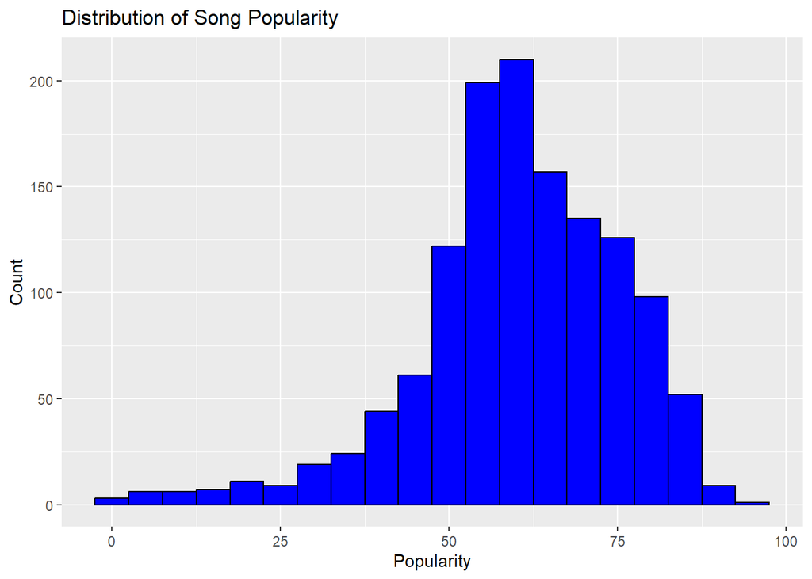

```r
ggplot(spotify_data, aes(x = popularity)) +
  geom_histogram(binwidth = 5, fill = 'blue', color = 'black') +
  labs(title = "Distribution of Song Popularity", x = "Popularity", y = "Count")
```

## Loudness vs Energy

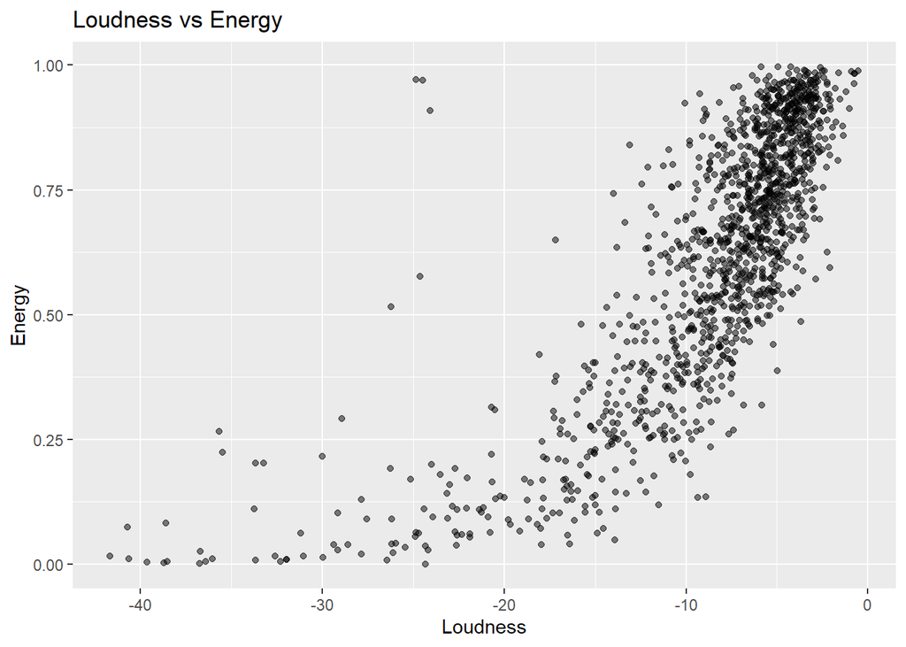

```r
ggplot(spotify_data, aes(x = loudness, y = energy)) +
  geom_point(alpha = 0.5) +
  labs(title = "Loudness vs Energy", x = "Loudness", y = "Energy")
```

The scatter plot graph titled “Loudness vs Energy” shows that as loudness increases (values becoming less negative), energy tends to increase as well. This is indicated by the clustering of data points towards the top right of the graph, suggesting a positive correlation between loudness and energy.

## Unique Insights from Feature Counts Dataset

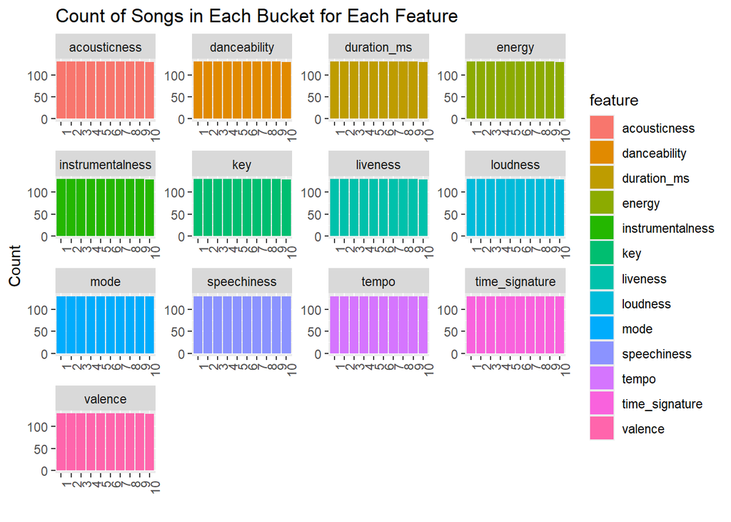

```r
bucketed_counts_long <- bucketed_counts %>%
  mutate(bucket = as.factor(bucket))

ggplot(bucketed_counts_long, aes(x = bucket, y = count, fill = feature)) +
  geom_bar(stat="identity")+
  facet_wrap(~ feature, scales = "free") +
  labs(title = "Count of Songs in Each Bucket for Each Feature", x = "", y = "Count") +
  theme(axis.text.x = element_text(angle = 90, hjust = 1))
```

Based on the bar graphs, it can be observed that all of the musical features have a balanced distribution(Natev, n.d.c) of songs across different categories. This suggests that there is a diverse range of music being produced and enjoyed, with no single attribute dominating the landscape.

## Unique Insights from Average Popularity Dataset

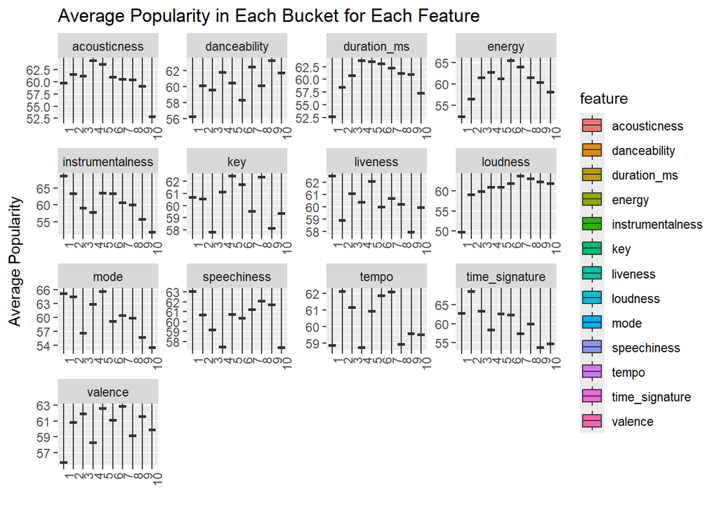

```r
bucketed_avg_popularity_long <- bucketed_avg_popularity %>%
  mutate(bucket = as.factor(bucket))

ggplot(bucketed_avg_popularity_long, aes(x = bucket, y = avg_popularity, fill = feature)) +
  geom_boxplot(ymin=0,ymax=100) +
  facet_wrap(~ feature, scales = "free") +
  labs(title = "Average Popularity in Each Bucket for Each Feature", x = "", y = "Average Popularity") +
  theme(axis.text.x = element_text(angle = 90, hjust = 1))
```

# Conclusion

This study(Natev, n.d.b) demonstrates the potential of using Spotify metadata and exploratory data analysis to gain insights into the factors influencing song popularity. Further research using machine learning models(Natev, n.d.a) could refine these insights and improve predictions of hit songs. Future work might involve incorporating additional features such as lyrical content or user engagement metrics to enhance predictive accuracy and broaden understanding within the music industry.

## References

Lamere, Paul. n.d. “Spotify API for Python, Spotipy.” https://spotipy.readthedocs.io/en/2.24.0/.

Natev, Andrej. n.d.a. “First Phase Notebook.” https://www.kaggle.com/code/andrejnatev/hit-song-prediction.

———. n.d.b. “Hit Song Prediction Using Machine Learning and Spotify.”

———. n.d.c. “Second Phase Notebook.” https://www.kaggle.com/code/andrejnatev/spotify-api-spotipy-hit-song-prediction.